# Instacart Market Basket Challenge

### Jean-Pierre Rouhana and Chiemi Kato

#### San Francisco State University, Statistical Learning & Data Mining 2019

## Introduction - Instacart Background

- Instacart is a grocery ordering and delivery service app, which aims to make the process of ordering groceries more convenient for stores and shoppers
- Shoppers place orders to partnering stores (ie Whole Foods, Trader Joe’s, etc.) and are connected to in-person shoppers who drive to the store location and purchase and deliver the goods
- Instacart shoppers are able to use the grocery delivery service for a one-time fee of \$3.99, or for free if they have a membership (\$99/year) and orders are above \$35

[figure not shown]

## About the Data

- The data set was released by Instacart as a machine learning competition via Kaggle
- The data sets consisted of over 3 million grocery orders of anonymized information based on the products that belong to each order, and the orders that belong to each user
- Additionally there was also information the times and days the orders were placed, the relative amount of time between orders per user, grocery department and aisle information, and the sequence of the products being placed in the basket
- The goal of the kaggle competition was to predict which items were likely to be reordered again by the same customers

## Exploratory Data Analysis

The files provide a combination of categorical data, both ordinal and nominal pertaining to the features of the actual goods being ordered such as “dairy,” “produce,” “organic,” etc.

```r
head(products, n=10)
length(unique(products$product_id)) # 49688 total products
```

A data.frame: 10 × 4

| product_id <int> | product_name <fct> | aisle_id <int> | department_id <int> |
| --- | --- | --- | --- |
| 1 | Chocolate Sandwich Cookies | 61 | 19 |
| 2 | All-Seasons Salt | 104 | 13 |
| 3 | Robust Golden Unsweetened Oolong Tea | 94 | 7 |
| 4 | Smart Ones Classic Favorites Mini Rigatoni With Vodka Cream Sauce | 38 | 1 |
| 5 | Green Chile Anytime Sauce | 5 | 13 |
| 6 | Dry Nose Oil | 11 | 11 |
| 7 | Pure Coconut Water With Orange | 98 | 7 |
| 8 | Cut Russet Potatoes Steam N' Mash | 116 | 1 |
| 9 | Light Strawberry Blueberry Yogurt | 120 | 16 |
| 10 | Sparkling Orange Juice & Prickly Pear Beverage | 115 | 7 |

49688

```r
head(order_products_train, n=15)
```

| order_id | product_id | add_to_cart_order | reordered |
| --- | --- | --- | --- |
| 1 | 49302 | 1 | 1 |
| 1 | 11109 | 2 | 1 |
| 1 | 10246 | 3 | 0 |
| 1 | 49683 | 4 | 0 |
| 1 | 43633 | 5 | 1 |
| 1 | 13176 | 6 | 0 |
| 1 | 47209 | 7 | 0 |
| 1 | 22035 | 8 | 1 |
| 36 | 39612 | 1 | 0 |
| 36 | 19660 | 2 | 1 |
| 36 | 49235 | 3 | 0 |
| 36 | 43086 | 4 | 1 |
| 36 | 46620 | 5 | 1 |
| 36 | 34497 | 6 | 1 |
| 36 | 48679 | 7 | 1 |

```r
head(orders, n=5)
```

A data.frame: 5 × 7

| order_id <int> | user_id <int> | eval_set <fct> | order_number <int> | order_dow <int> | order_hour_of_day <int> | days_since_prior_order <int> |
| --- | --- | --- | --- | --- | --- | --- |
| 2539329 | 1 | prior | 1 | 2 | 8 | NA |
| 2398795 | 1 | prior | 2 | 3 | 7 | 15 |
| 473747 | 1 | prior | 3 | 3 | 12 | 21 |
| 2254736 | 1 | prior | 4 | 4 | 7 | 29 |
| 431534 | 1 | prior | 5 | 4 | 15 | 28 |

### Days of the week when people order

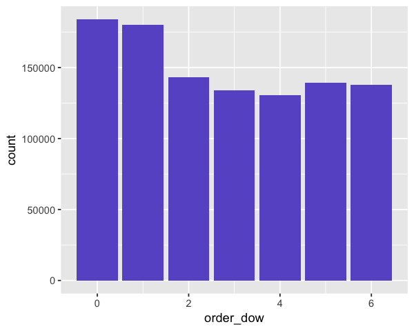

```r
orders %>%
  ggplot(aes(x=order_dow, height=.2)) +
  geom_histogram(stat="count",fill="slateblue", position=position_dodge(width=1))
```

### Relative Time Between Orders

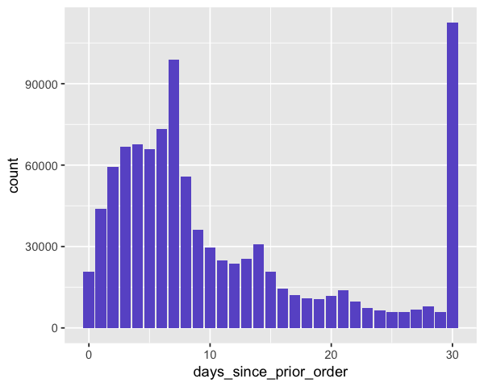

```r
orders %>%
  ggplot(aes(x=days_since_prior_order)) +
geom_histogram(stat="count",fill="slateblue")
```

### What are the most popular items ordered on Instacart?

```r
mostcommon <- order_products_train %>%
  group_by(product_id) %>%
  summarize(count = n()) %>%
  top_n(10, wt = count) %>%
  left_join(select(products,product_id,product_name),by="product_id") %>%
  arrange(desc(count))

head(mostcommon, n=10)
```

A tibble: 10 × 3

| product_id <int> | count <int> | product_name <fct> |
| --- | --- | --- |
| 24852 | 18726 | Banana |
| 13176 | 15480 | Bag of Organic Bananas |
| 21137 | 10894 | Organic Strawberries |
| 21903 | 9784 | Organic Baby Spinach |
| 47626 | 8135 | Large Lemon |
| 47766 | 7409 | Organic Avocado |
| 47209 | 7293 | Organic Hass Avocado |
| 16797 | 6494 | Strawberries |
| 26209 | 6033 | Limes |
| 27966 | 5546 | Organic Raspberries |

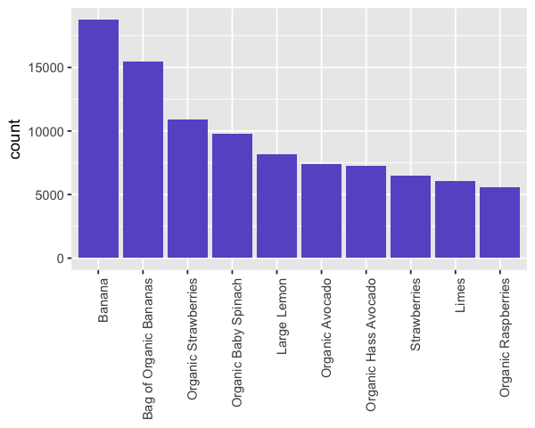

```r
mostcommon %>%
  ggplot(aes(x=reorder(product_name,-count), y=count))+
  geom_bar(stat="identity",fill="slateblue")+
theme(axis.text.x=element_text(angle=90, hjust=1),axis.title.x = element_blank())
```

### What items are most often reordered?

```r
item_reorders <- order_products_train %>%
  group_by(product_id) %>%
  summarize(proportion_reordered = mean(reordered), n=n()) %>%
  filter(n>40) %>%
  top_n(10,wt=proportion_reordered) %>%
  arrange(desc(proportion_reordered)) %>%
  left_join(products,by="product_id")

head(data.frame(item_reorders), n=15)
```

A data.frame: 10 × 6

| product_id <int> | proportion_reordered <dbl> | n <int> | product_name <fct> | aisle_id <int> | department_id <int> |
| --- | --- | --- | --- | --- | --- |
| 1729 | 0.9347826 | 92 | 2% Lactose Free Milk | 84 | 16 |
| 20940 | 0.9130435 | 368 | Organic Low Fat Milk | 84 | 16 |
| 12193 | 0.8983051 | 59 | 100% Florida Orange Juice | 98 | 7 |
| 21038 | 0.8888889 | 81 | Organic Spelt Tortillas | 128 | 3 |
| 31764 | 0.8888889 | 45 | Original Sparkling Seltzer Water Cans | 115 | 7 |
| 24852 | 0.8841717 | 18726 | Banana | 24 | 4 |
| 117 | 0.8833333 | 120 | Petit Suisse Fruit | 2 | 16 |
| 39180 | 0.8819876 | 483 | Organic Lowfat 1% Milk | 84 | 16 |
| 12384 | 0.8810409 | 269 | Organic Lactose Free 1% Lowfat Milk | 91 | 16 |
| 24024 | 0.8785249 | 461 | 1% Lowfat Milk | 84 | 16 |

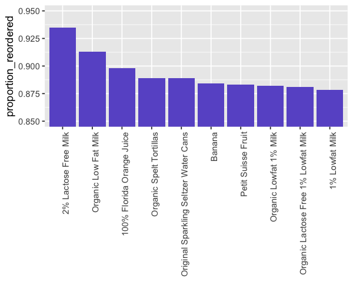

```r
item_reorders %>%
  ggplot(aes(x=reorder(product_name,-proportion_reordered), y=proportion_reordered))+
  geom_bar(stat="identity",fill="slateblue")+
  theme(axis.text.x=element_text(angle=90, hjust=1),axis.title.x = element_blank())+coord_cartesian(ylim=c(0.85,0.95))
```

## Proportion of Products Reordered

[output not shown]

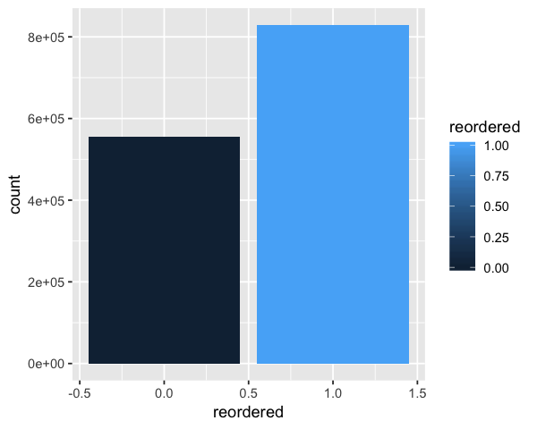

```r
reorder %>%
  ggplot(aes(x=reordered,y=count, fill=reordered))+
geom_bar(stat="identity")
```

```r
reorder.table<- order_products_train %>%
  count(reordered) %>%
  mutate(prop = prop.table(n))

as.data.frame(reorder.table)

reorder <- order_products_train %>%
  group_by(reordered) %>%
  summarize(count = n()) %>%
  mutate(proportion = count/sum(count))
```

A data.frame: 2 × 3

| reordered <int> | n <int> | prop <dbl> |
| --- | --- | --- |
| 0 | 555793 | 0.4014056 |
| 1 | 828824 | 0.5985944 |

## Limitations:

- When working with such a large data set, iterative techniques such as cross-validation become a very challenging task. These methods are computationally expensive and many of these techniques are beyond our resources if we want to use the original data set we were given
- For example: Cross-Validation, Stepwise Regression, ROC graph/threshold determination, diagnostic plotting

## Codes Examples that didn't complete:

#### ROC

install.packages("pROC") library(pROC) plot(roc(Test.Orders$reordered, PredM1 , direction=">"), #col="yellow", lwd=3, main="Reordering ROC")

## Preprocessing

### Main Approach to Organizing the Variables

#### 1. Feature Engineering

We had to think about what variables could be created to help us solve our problem - (which is to predict the probability of a user reordering a specific product/of a product being reordered).

#### 2. Selection of Variables

- Some of the variables we were able to automatically take out, since they were either originally created for referential purposes only (ie eval_set, user_id, order_id, order_number, product_name)
- Others we took out since we had already created information about the users and proportion of reordered items across for each product
- Out of aisle, product, and departmental categories for the products, we decided to keep only one of these variables, since they are all correlated and related to one another

#### 3. Null Values: Non-random Missing Data

- The variable days_since_prior_order had a large number of null values. We had originally omitted them from the data set, but after further evaluation, we saw that these null values actually had a meaning.
- We realized that every null value in the days_since_prior_order corresponded to the first order made by each of the users. The reason this column gave null values is before it represents a relative amount of time and there was no "prior" order to measure this time unit.
- Since we were only looking to examine data that involved reordered products, we decided that eliminating all of the first orders from the data set would not pose a huge problem to our analysis

#### Original Data Sets

```r
head(orders)
head(order_products_prior)
```

A data.frame: 6 × 7

| order_id <int> | user_id <int> | eval_set <fct> | order_number <int> | order_dow <int> | order_hour_of_day <int> | days_since_prior_order <int> |
| --- | --- | --- | --- | --- | --- | --- |
| 2539329 | 1 | prior | 1 | 2 | 8 | NA |
| 2398795 | 1 | prior | 2 | 3 | 7 | 15 |
| 473747 | 1 | prior | 3 | 3 | 12 | 21 |
| 2254736 | 1 | prior | 4 | 4 | 7 | 29 |
| 431534 | 1 | prior | 5 | 4 | 15 | 28 |
| 3367565 | 1 | prior | 6 | 2 | 7 | 19 |

A data.frame: 6 × 4

| order_id <int> | product_id <int> | add_to_cart_order <int> | reordered <int> |
| --- | --- | --- | --- |
| 2 | 33120 | 1 | 1 |
| 2 | 28985 | 2 | 1 |
| 2 | 9327 | 3 | 0 |
| 2 | 45918 | 4 | 1 |
| 2 | 30035 | 5 | 0 |
| 2 | 17794 | 6 | 1 |

#### Updated Data Sets

```r
head(Combined.Orders, n=10)
```

A data.frame: 10 × 18

| user_id <fct> | user_prop_reordered <dbl> | total_orders <int> | product_id <int> | product_orders <int> | proportion_reordered <dbl> | order_id <int> | add_to_cart_order <int> | reordered <fct> | eval_set <fct> | order_number <int> | order_dow <fct> | order_hour_of_day <dbl> | days_since_prior_order <int> | product_name <fct> | aisle_id <int> | department_id <int> | reordered.Num <dbl> |
| --- | --- | --- | --- | --- | --- | --- | --- | --- | --- | --- | --- | --- | --- | --- | --- | --- | --- |
| 1 | 1.728571 | 70 | 46149 | 2699 | 1.810671 | 1187899 | 11 | 1 | train | 11 | 4 | 8 | 14 | Zero Calorie Cola | 77 | 7 | 2 |
| 1 | 1.728571 | 70 | 26405 | 405 | 1.429630 | 1187899 | 4 | 1 | train | 11 | 4 | 8 | 14 | XL Pick-A-Size Paper Towel Rolls | 54 | 17 | 2 |
| 1 | 1.728571 | 70 | 10258 | 569 | 1.690685 | 431534 | 3 | 1 | prior | 5 | 4 | 15 | 28 | Pistachios | 117 | 19 | 2 |
| 1 | 1.728571 | 70 | 196 | 11936 | 1.785690 | 3367565 | 1 | 1 | prior | 6 | 2 | 7 | 19 | Soda | 77 | 7 | 2 |
| 1 | 1.728571 | 70 | 30450 | 7286 | 1.586467 | 473747 | 5 | 0 | prior | 3 | 3 | 12 | 21 | Creamy Almond Butter | 88 | 13 | 1 |
| 1 | 1.728571 | 70 | 12427 | 2059 | 1.739679 | 550135 | 3 | 1 | prior | 7 | 1 | 9 | 20 | Original Beef Jerky | 23 | 19 | 2 |
| 1 | 1.728571 | 70 | 12427 | 2059 | 1.739679 | 2398795 | 3 | 1 | prior | 2 | 3 | 7 | 15 | Original Beef Jerky | 23 | 19 | 2 |
| 1 | 1.728571 | 70 | 26405 | 405 | 1.429630 | 2254736 | 5 | 1 | prior | 4 | 4 | 7 | 29 | XL Pick-A-Size Paper Towel Rolls | 54 | 17 | 2 |
| 1 | 1.728571 | 70 | 26088 | 851 | 1.537015 | 2398795 | 5 | 1 | prior | 2 | 3 | 7 | 15 | Aged White Cheddar Popcorn | 23 | 19 | 2 |
| 1 | 1.728571 | 70 | 13032 | 1131 | 1.639257 | 2398795 | 6 | 0 | prior | 2 | 3 | 7 | 15 | Cinnamon Toast Crunch | 121 | 14 | 1 |

## Splitting the Data

```r
set.seed(1)
Train<- sample(1:nrow(Combined.Orders), nrow(Combined.Orders)*.8)
Training.Orders <- Combined.Orders[Train,]
Test.Orders <- Combined.Orders[-Train,]
```

```r
nrow(Training.Orders)
nrow(Test.Orders)
```

7771023

1942756

## Model 1: Logistic Regression

```r
Logistic.TestModel2 <- glm(reordered ~ user_prop_reordered + proportion_reordered + product_orders + total_orders + add_to_cart_order + order_dow + days_since_prior_order + department_id, family = binomial, data = Training.Orders)
summary(Logistic.TestModel2)
```

[figure not shown]

```r
departments
```

A data.frame: 21 × 2

| department_id <int> | department <fct> |
| --- | --- |
| 1 | frozen |
| 2 | other |
| 3 | bakery |
| 4 | produce |
| 5 | alcohol |
| 6 | international |
| 7 | beverages |
| 8 | pets |
| 9 | dry goods pasta |
| 10 | bulk |
| 11 | personal care |
| 12 | meat seafood |
| 13 | pantry |
| 14 | breakfast |
| 15 | canned goods |
| 16 | dairy eggs |
| 17 | household |
| 18 | babies |
| 19 | snacks |
| 20 | deli |
| 21 | missing |

## Model Performance

### Prediction and Accuracy

```r
attach(Combined.Orders)
set.seed(1)

Accuracy <- function(table)
{
 n11 <- table[1,1]
 n22 <- table[2,2]
 Total <- table[1,1]+table[2,2]+table[2,1]+table[1,2]
 Total
 return((n11+n22)/Total)
}
```

```r
ProbM1 <- predict.glm(Logistic.TestModel1, newdata = Test.Orders, type = "response")
PredM1 <- ifelse(ProbM1 > .5, "1" , "0")
TableM1 <- table(PredM1, Test.Orders$reordered)
TableM1
Accuracy(TableM1)
```

[output not shown]

0.729818434100915

### Deviance Test Against the Null Model

```r
Null.TestModel2 <- glm(reordered ~ 1, family = binomial, data = Training.Orders)

summary(Null.TestModel2)
```

```
Call:
glm(formula = reordered ~ 1, family = binomial, data = Training.Orders)

Deviance Residuals:
    Min       1Q   Median       3Q      Max
-1.4092  -1.4092   0.9621   0.9621   0.9621

Coefficients:
             Estimate Std. Error z value Pr(>|z|)
(Intercept) 0.5300206  0.0007428   713.6   <2e-16 ***
---
Signif. codes:  0 ‘***’ 0.001 ‘**’ 0.01 ‘*’ 0.05 ‘.’ 0.1 ‘ ’ 1

(Dispersion parameter for binomial family taken to be 1)

    Null deviance: 10245747  on 7771022  degrees of freedom
Residual deviance: 10245747  on 7771022  degrees of freedom
AIC: 10245749

Number of Fisher Scoring iterations: 4
```

```r
anova(Null.TestModel2, Logistic.TestModel2, test='Chisq')
```

A anova: 2 × 5

| Resid. Df <dbl> | Resid. Dev <dbl> | Df <dbl> | Deviance <dbl> | Pr(>Chi) <dbl> |
| --- | --- | --- | --- | --- |
| 7771022 | 10245747 | NA | NA | NA |
| 7770990 | 8321585 | 32 | 1924161 | 0 |

## Model 2: Classification Tree

```r
library(rpart)
```

```r
Tree.TestModel <- rpart(reordered ~ user_prop_reordered + proportion_reordered + product_orders + total_orders + add_to_cart_order + order_dow + days_since_prior_order + department_id,method = "class", data = Training.Orders)

plot(Tree.TestModel)
text(Tree.TestModel)

Pred.Tree <- predict(Tree.TestModel, newdata = Test.Orders, type = "class")
Tree.Table <- table(Pred.Tree, Test.Orders$reordered)
Tree.Table

Accuracy(Tree.Table)
```

[output not shown]

0.706618401550564

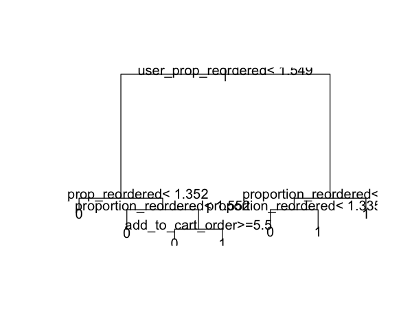

[figure not shown]

## Model 3: Support Vector Machine Model

```r
set.seed(1)
Trying <- sample(1:nrow(Combined.Orders), nrow(Combined.Orders)*.001)
DF <- Combined.Orders[Trying,]
Train.Trying <- sample(1:nrow(DF), nrow(DF)*.8)
Trying.DF.Train <- DF[Train.Trying, ]
Trying.DF.Test <- DF[-Train.Trying, ]
```

```r
SVM.TestModel <- svm(reordered ~ user_prop_reordered + proportion_reordered + product_orders + total_orders + add_to_cart_order + order_dow + days_since_prior_order + department_id.x, data = Trying.DF.Train)
```

```r
summary(SVM.TestModel)
```

[output not shown]

```r
SVM.Pred <- predict(SVM.TestModel, Trying.DF.Test)
SVM.Table <- table(SVM.Pred, Trying.DF.Test$reordered)

Accuracy(SVM.Table)
```

0.739063304168811

## Conclusion

Model 1: Logistic Regression - 0.7298

Model 2: Classification Tree - 0.7066

Model 3: SVM - 0.7391 on .1% of the data

### References:

https://www.kaggle.com/c/instacart-market-basket-analysis

https://tech.instacart.com/3-million-instacart-orders-open-sourced-d40d29ead6f2